# Survival analysis

# Survival analysis of ovarian dataset

In this project we will conducted survival analysis of *ovarian dataset* from **survival** package. The dataset includes information about patients with ovarian cancer and clinical information, including the time that patients were tracked until they died or were lost to follow-up, age of the patient, prescription of the treatment group, presence of residual disease, where patients were censored or not, and working performance.

Let’s start with short EDA.

## EDA

Let’s see the structure of the dataset.

```
## Rows: 26
## Columns: 6
## $ futime   <dbl> 59, 115, 156, 421, 431, 448, 464, 475, 477, 563, 638, 744,...
## $ fustat   <dbl> 1, 1, 1, 0, 1, 0, 1, 1, 0, 1, 1, 0, 0, 0, 0, 0, 0, 0, 0, 0...
## $ age      <dbl> 72.3315, 74.4932, 66.4658, 53.3644, 50.3397, 56.4301, 56.9...
## $ resid.ds <dbl> 2, 2, 2, 2, 2, 1, 2, 2, 2, 1, 1, 1, 2, 2, 1, 1, 2, 1, 1, 2...
## $ rx       <dbl> 1, 1, 1, 2, 1, 1, 2, 2, 1, 2, 1, 2, 2, 2, 1, 1, 1, 1, 2, 2...
## $ ecog.ps  <dbl> 1, 1, 2, 1, 1, 2, 2, 2, 1, 2, 2, 1, 2, 1, 1, 2, 2, 1, 1, 1...
```

Description for each variable:

- **futime:** survival or censoring time (the time patients were tracked until they either died or were lost to follow-up)
- **fustat:** censoring status
- **age:** in years
- **resid.ds:** residual disease present (1=no,2=yes)
- **rx:** treatment group
- **ecog.ps:** ECOG performance status (1 is better, see reference)

This dataset has 6 numerical variables: **futime, fustat, age, resid.ds, rx, ecog.ps** with **26** observations in each column. Thus 26 patients were involved in the experiment. Also we see that variables **rx**, **resid.ds** and **ecog.ps** have two levels. Thus it is required to convert the values to factor type. We convert variable `rx` (treatment group) to factor with labels “A” and “B”, `resid.ds` (residual disease present), where 1 - “no” and 2 - “yes”, `ecog.ps` (ECOG performance status), where 1 - good, 2 - bad.

The dataset doesn’t have missing values.

```
## [1] 0
```

Let us look at the overall distribution of age values.  
*Fig. 1*

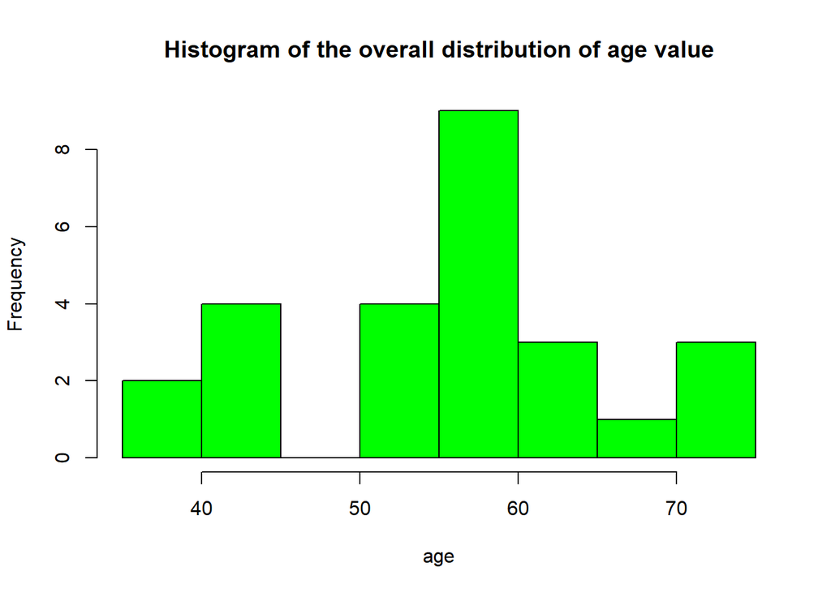

It seems that data has a bimodal distribution. We can divide patients into two groups: more 50 age and less.

## The Kaplan Meier Curves

The Kaplan–Meier estimator is a non-parametric statistic used to estimate the survival function from lifetime data. In medical research, it is often used to measure the fraction of patients living for a certain amount of time after treatment.

We get survival timeline.

```
##  [1]   59   115   156   421+  431   448+  464   475   477+  563   638   744+
## [13]  769+  770+  803+  855+ 1040+ 1106+ 1129+ 1206+ 1227+  268   329   353
## [25]  365   377+
```

```
## Call: survfit(formula = Surv(futime, fustat) ~ 1, data = data)
##
##  time n.risk n.event survival std.err lower 95% CI upper 95% CI
##     1     26       0    1.000  0.0000        1.000        1.000
##    30     26       0    1.000  0.0000        1.000        1.000
##    60     25       1    0.962  0.0377        0.890        1.000
##    90     25       0    0.962  0.0377        0.890        1.000
##   180     23       2    0.885  0.0627        0.770        1.000
##   270     22       1    0.846  0.0708        0.718        0.997
##   360     20       2    0.769  0.0826        0.623        0.949
##   450     15       2    0.688  0.0919        0.529        0.894
##   540     12       2    0.596  0.0999        0.429        0.828
##   630     11       1    0.546  0.1032        0.377        0.791
##   720     10       1    0.497  0.1051        0.328        0.752
##   810      6       0    0.497  0.1051        0.328        0.752
##   900      5       0    0.497  0.1051        0.328        0.752
```

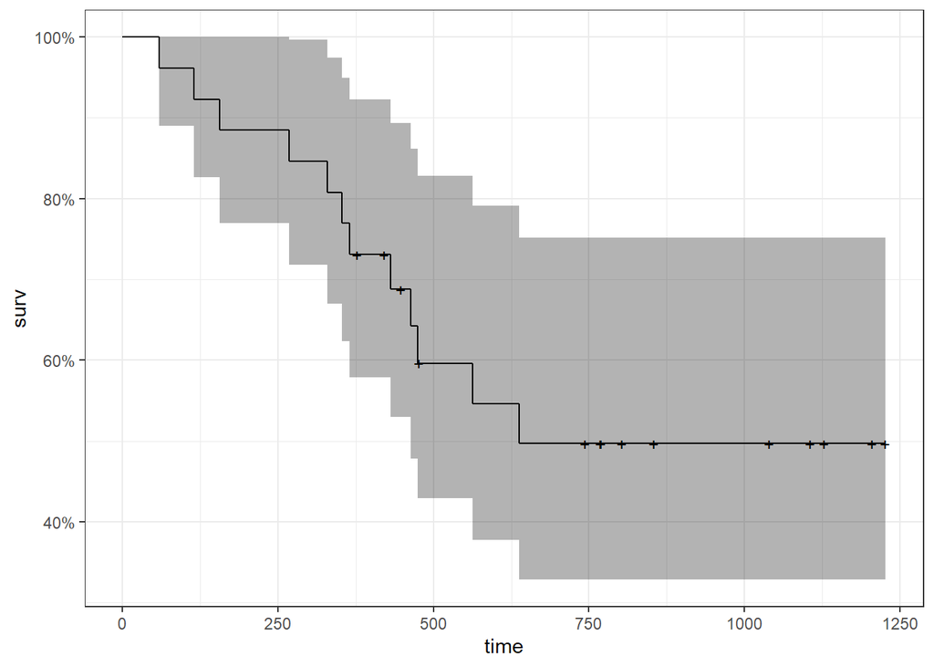

Let’s see how the type of treatment affects survival. We see that treatment 2 (B) had a greater impact on patients. However it seems that differences are not very significant. To check it we will use log-rank test later.

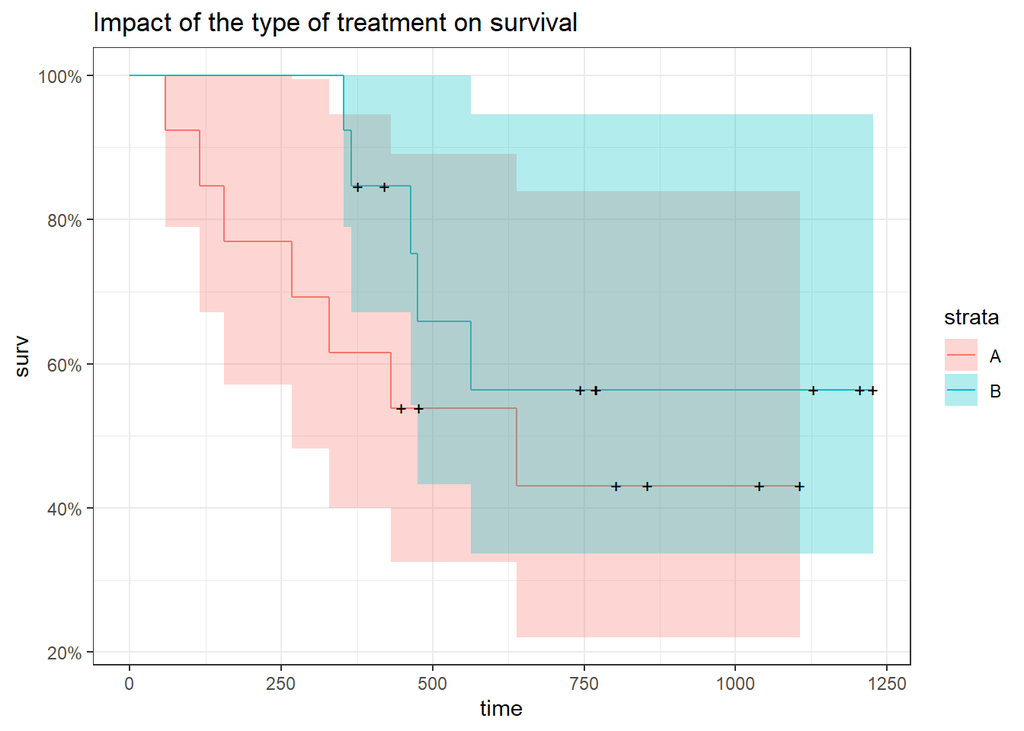

Do the same for variables `ecog.ps` and `resid.ds`.  
For variable `ecog.ps`. It is difficult to assess the influence of the factor on survival. However it seems that patients with “status 2” have a lower survival compared with patients with “status 1” (by the end of period).

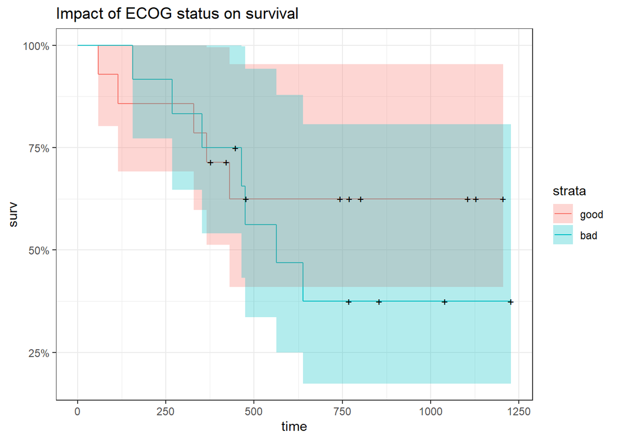

For variabe `resid.ds`. We see on the plot that patients without residual disease show the best survival rate.

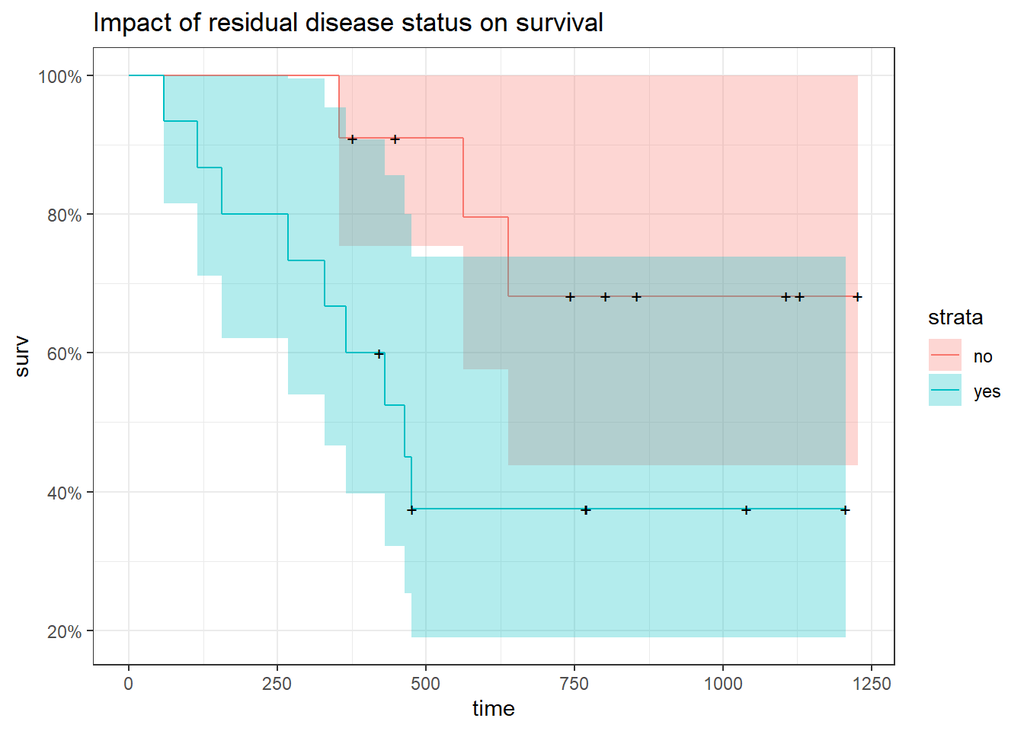

In addition we will divide patients by age, into those who are under 50 years old and over 50 years old. It can be noted that the probability of living more than a year in patients aged less than 50 years is higher than in older patients.

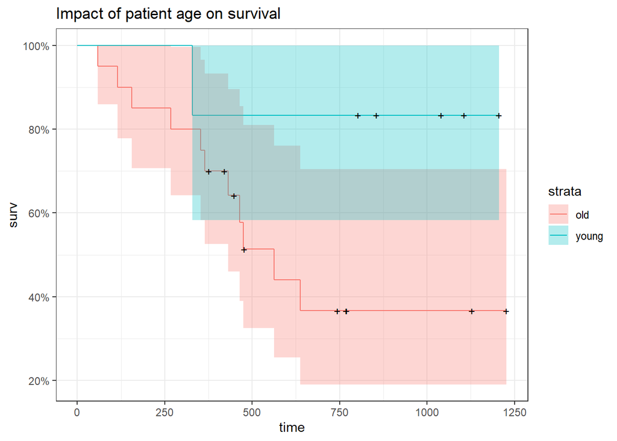

```
##    futime fustat     age resid.ds rx ecog.ps age_group hybrid_var
## 1      59      1 72.3315      yes  A    good       old      old A
## 2     115      1 74.4932      yes  A    good       old      old A
## 3     156      1 66.4658      yes  A     bad       old      old A
## 4     421      0 53.3644      yes  B    good       old      old B
## 5     431      1 50.3397      yes  A    good       old      old A
## 6     448      0 56.4301       no  A     bad       old      old A
## 7     464      1 56.9370      yes  B     bad       old      old B
## 8     475      1 59.8548      yes  B     bad       old      old B
## 9     477      0 64.1753      yes  A    good       old      old A
## 10    563      1 55.1781       no  B     bad       old      old B
## 11    638      1 56.7562       no  A     bad       old      old A
## 12    744      0 50.1096       no  B    good       old      old B
## 13    769      0 59.6301      yes  B     bad       old      old B
## 14    770      0 57.0521      yes  B    good       old      old B
## 15    803      0 39.2712       no  A    good     young    young A
## 16    855      0 43.1233       no  A     bad     young    young A
## 17   1040      0 38.8932      yes  A     bad     young    young A
## 18   1106      0 44.6000       no  A    good     young    young A
## 19   1129      0 53.9068       no  B    good       old      old B
## 20   1206      0 44.2055      yes  B    good     young    young B
## 21   1227      0 59.5890       no  B     bad       old      old B
## 22    268      1 74.5041      yes  A     bad       old      old A
## 23    329      1 43.1370      yes  A    good     young    young A
## 24    353      1 63.2192       no  B     bad       old      old B
## 25    365      1 64.4247      yes  B    good       old      old B
## 26    377      0 58.3096       no  B    good       old      old B
```

```
##   old A   old B young A young B
##       8      12       5       1
```

## Long-rank tests, group comparison

Another method for assessing survival is the log-rank test. It allows you to compare whether there is a difference in survival between groups. For this purpose we will use `survdiff` function. Previously we weren’t sure about result of survival curve where we assessed impact of the type of treatment on survival.

```
## Call:
## survdiff(formula = Surv(futime, fustat) ~ rx, data = data)
##
##       N Observed Expected (O-E)^2/E (O-E)^2/V
## rx=A 13        7     5.23     0.596      1.06
## rx=B 13        5     6.77     0.461      1.06
##
##  Chisq= 1.1  on 1 degrees of freedom, p= 0.3
```

In order to dispel doubts, we will perform a log rank test. We will use `longrank_test` (package coin) to answer the question ‘whether the survival rate differ in dependence of type of treatment’. We see that there is not a statistical significant differences between the groups.

```
##
##  Asymptotic Two-Sample Logrank Test
##
## data:  Surv(futime, fustat) by rx (A, B)
## Z = -1.0296, p-value = 0.3032
## alternative hypothesis: true theta is not equal to 1
```

Groups with ECOG status 1 and 2 don’t show significant differences in survival:

```
##
##  Asymptotic Two-Sample Logrank Test
##
## data:  Surv(futime, fustat) by ecog.ps (good, bad)
## Z = 0.69106, p-value = 0.4895
## alternative hypothesis: true theta is not equal to 1
```

For residual disease status groups. There is no significant differences in surviving between groups too.

```
##
##  Asymptotic Two-Sample Logrank Test
##
## data:  Surv(futime, fustat) by resid.ds (no, yes)
## Z = 1.9234, p-value = 0.05444
## alternative hypothesis: true theta is not equal to 1
```

## Assessment of risk factors (Cox model)

The Cox proportional-hazards model (Cox, 1972) is essentially a regression model commonly used statistical in medical research for investigating the association between the survival time of patients and one or more predictor variables.

```
## Call:
## coxph(formula = Surv(futime, fustat) ~ rx + age + resid.ds +
##     ecog.ps, data = data)
##
##   n= 26, number of events= 12
##
##                 coef exp(coef) se(coef)      z Pr(>|z|)
## rxB         -0.91450   0.40072  0.65332 -1.400  0.16158
## age          0.12481   1.13294  0.04689  2.662  0.00777 **
## resid.dsyes  0.82619   2.28459  0.78961  1.046  0.29541
## ecog.psbad   0.33621   1.39964  0.64392  0.522  0.60158
## ---
## Signif. codes:  0 '***' 0.001 '**' 0.01 '*' 0.05 '.' 0.1 ' ' 1
##
##             exp(coef) exp(-coef) lower .95 upper .95
## rxB            0.4007     2.4955    0.1114     1.442
## age            1.1329     0.8827    1.0335     1.242
## resid.dsyes    2.2846     0.4377    0.4861    10.738
## ecog.psbad     1.3996     0.7145    0.3962     4.945
##
## Concordance= 0.807  (se = 0.068 )
## Likelihood ratio test= 17.04  on 4 df,   p=0.002
## Wald test            = 14.25  on 4 df,   p=0.007
## Score (logrank) test = 20.81  on 4 df,   p=3e-04
```

Visualization of model summary.

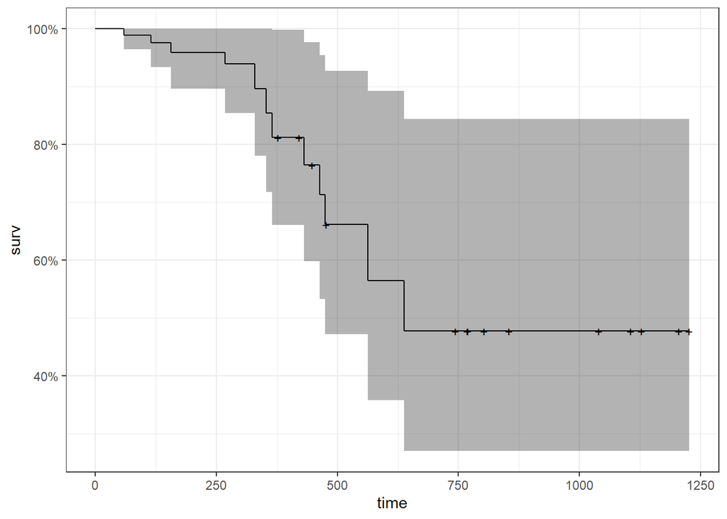

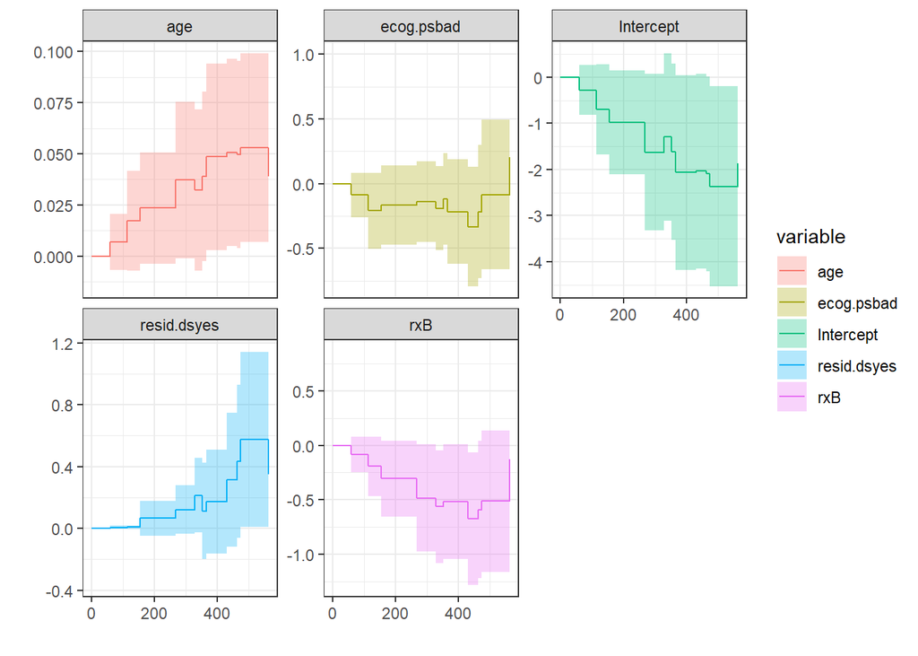

Then we will build Cox proportional hazards model using the `coxph function`. To visualize model we will use the `ggforest`.

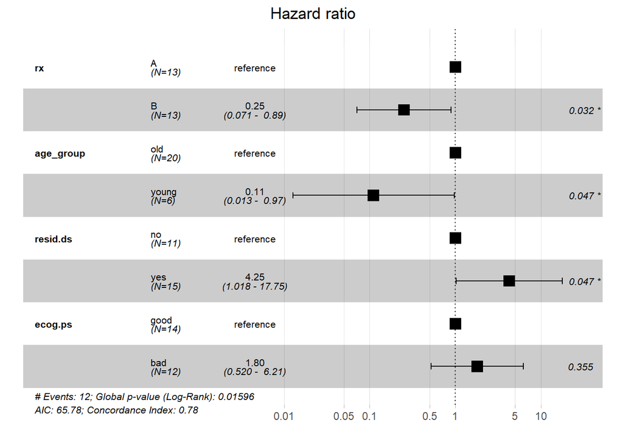